# Motivation

The `faintr` package provides convenience function for the evaluation of a model fit, obtained with the `brms` package, for a Bayesian regression model for data from a factorial design. The `faintr` package allows extraction of many meaningful comparisons irrespective of the coding in the model. This is done by directly extracting the design matrix from the model.

# Installation

Install the `faintr` package with `devtools` from GitHub:

```r
devtools::install_github(
  "n-kall/faintr",
  build_vignettes = TRUE
)
library(faintr)
```

# Example

Consider a data set on pitch frequency in the speech of female and male speakers in polite and informal contexts.

```r
library(tidyverse)
data(politeness)
```

The cell means of this data set are:

```r
politeness %>%
    group_by(gender, context) %>%
    summarize(mean_pitch = mean(pitch))
```

```
## # A tibble: 4 x 3
## # Groups:   gender [2]
##   gender context mean_pitch
##   <fct>  <fct>        <dbl>
## 1 F      inf           261.
## 2 F      pol           233.
## 3 M      inf           144.
## 4 M      pol           133.
```

A Bayesian regression model for a factorial design with by-subject and by-item random intercepts can be obtained with the `brms` package as follows:

```r
library(brms)
m_dummy <- brm(pitch ~ gender * context + (1 | subject + sentence), politeness)
```

The `brm` function uses dummy coding per default. Look at the estimated coefficients:

```r
fixef(m_dummy)
```

```
##                      Estimate Est.Error        Q2.5     Q97.5
## Intercept           261.20241 22.991502  215.328063 310.59304
## genderM            -116.80078 32.732559 -184.396115 -50.12933
## contextpol          -27.50320  8.128188  -43.519454 -11.43669
## genderM:contextpol   15.61577 11.591269   -7.268663  38.27043
```

The reference cell is where `gender == F` and `context == inf`, so female speakers in informal contexts. The estimated mean for the cell with data from male speakers in informal contexts is retrievable by adding the estimated coefficient `genderM` in the output above from the estimated Intercept.

The `faintr` package provides convenience functions to compare different (groups of) cells to each other, based on a model fit like the above. Although the fit of the regression model uses a particular reference cell for dummy-coding, other contrasts of relevance can be retrieved from the posterior samples. For example, if we want to compare two cell diagonally, say, male speakers in informal contexts against female speakers in polite contexts, we can do this by first filtering the specified draws.

```r
female_polite <- faintr::filter_draws(m_dummy, gender == "F", context == "pol")
male_informal <- faintr::filter_draws(m_dummy, gender == "M", context == "inf")
```

We can then calculate and visualise the difference between the specified groups.

```r
library(ggplot2)

diff <- pull(female_polite) - pull(male_informal)

mean(diff)
```

```
## [1] 89.29758
```

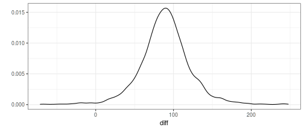

```r
qplot(diff, geom = "density")
```

Or we can plot the two posteriors for a visual comparison.

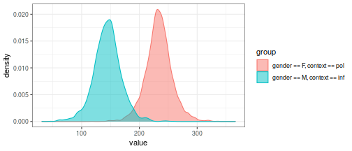

```r
library(ggplot2)

bind_cols(female_polite, male_informal) %>%
  gather(key = "group") %>%
  ggplot(aes(x = value, color = group, fill = group)) +
  geom_density(alpha = 0.5)
```

Alternatively, we could compare males and females over both contexts. This is done by leaving out the `context` variable from the specification.

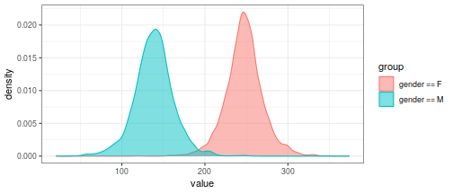

```r
male <- faintr::filter_draws(m_dummy, gender == "M")
female <- faintr::filter_draws(m_dummy, gender == "F")

bind_cols(female, male) %>%
  gather(key = "group") %>%
  ggplot(aes(x = value, color = group, fill = group)) +
  geom_density(alpha = 0.5)
```

```r
m_trt <- brm(pitch ~ 0 + gender * context + (1 | subject + sentence), politeness)
```

```r
fixef(m_trt)
```

```
##                     Estimate Est.Error       Q2.5     Q97.5
## genderF            260.08837 23.675030 211.154606 305.92303
## genderM            143.73242 23.639098  95.734842 191.54511
## contextpol         -27.44069  7.931049 -42.439222 -11.67704
## genderM:contextpol  15.60698 11.234455  -6.301486  37.07506
```

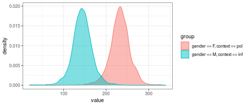

```r
female_polite <- faintr::filter_draws(m_trt, gender == "F", context == "pol")
male_informal <- faintr::filter_draws(m_trt, gender == "M", context == "inf")

bind_cols(female_polite, male_informal) %>%
  gather(key = "group") %>%
  ggplot(aes(x = value, color = group, fill = group)) +
  geom_density(alpha = 0.5)
```